# Grocery Sales Forecasting

Xilai Li, Shawn Hu, Shihan Li, Tianming Zhang

# project overview

1. Goal:to predict unit sales for each item from our randomly selected 82 items
2. Data selection methodology: due the the extremely large nature of all the datasets in our kaggle project, we randomly selected 82 items, 2% of total items for our modeling
3. Modeling methodlogy: we have used four linear regression models. First, we included every variable into our model as our base model. Second model we eminated all the variables that are collinear with other variables in our model to increase our efficiency. Third we estimate our model by using the weighted oil price to improve our our model efficiency based on two metrics R^2 and RMSE. eventually, we derive our final model by adding a quadratic variable oil price^2.

# Data Overview and Preparation

1. we removed all the lists andloaded all the libiraries that we need in this project.
2. we read all the files int to our r markdown including our items dataset, oil dataset, stores dataset, transaction dataset, training dataset, testing dataset, original dataset, and final dataset
3. we loaded our awesome_clean_train_data.RData

```r
rm(list = ls())
library(tidyverse)
library(data.table)
library(DataExplorer)
library(caret)
library(readr)
holidays <- read_csv("Data/holidays_events.csv")
items <- read_csv("Data/items.csv")
oil <- read_csv("Data/oil.csv")
stores <- read_csv("Data/stores.csv")
transactions <- read_csv("Data/transactions.csv")
training <- fread('Data/train.csv', header = T, sep = ',')
testing <- fread('Data/test.csv', header = T, sep = ",")
```

## Overviews of each sub-dataset

we use glimpse functions to see our sub datasets 1. stores dataset has 5 variables including sotre_nbr, city, state, type, and cluster. Here cluster refers to a group of similar stores. 2. items dataset has 4 variables: item_nbr, family class and perishable 3. transactions dataset has 3 varibales including date, store_nbr, transactions. Note: dates in our transanction dateset only covers training data

```r
glimpse(stores)
```

```
## Observations: 54
## Variables: 5
## $ store_nbr <int> 1, 2, 3, 4, 5, 6, 7, 8, 9, 10, 11, 12, 13, 14, 15, 1...
## $ city      <chr> "Quito", "Quito", "Quito", "Quito", "Santo Domingo",...
## $ state     <chr> "Pichincha", "Pichincha", "Pichincha", "Pichincha", ...
## $ type      <chr> "D", "D", "D", "D", "D", "D", "D", "D", "B", "C", "B...
## $ cluster   <int> 13, 13, 8, 9, 4, 13, 8, 8, 6, 15, 6, 15, 15, 7, 15, ...
```

```r
glimpse(items)
```

```
## Observations: 4,100
## Variables: 4
## $ item_nbr   <int> 96995, 99197, 103501, 103520, 103665, 105574, 10557...
## $ family     <chr> "GROCERY I", "GROCERY I", "CLEANING", "GROCERY I", ...
## $ class      <int> 1093, 1067, 3008, 1028, 2712, 1045, 1045, 1045, 104...
## $ perishable <int> 0, 0, 0, 0, 1, 0, 0, 0, 0, 0, 0, 0, 0, 0, 0, 1, 1, ...
```

```r
glimpse(transactions)
```

```
## Observations: 83,488
## Variables: 3
## $ date         <date> 2013-01-01, 2013-01-02, 2013-01-02, 2013-01-02, ...
## $ store_nbr    <int> 25, 1, 2, 3, 4, 5, 6, 7, 8, 9, 10, 11, 12, 13, 14...
## $ transactions <int> 770, 2111, 2358, 3487, 1922, 1903, 2143, 1874, 32...
```

we use glimpse functions to see our holidays dataset 1. Holidays data consists of 6 variables: date, type, locale, locale_name, description and transferred. 2.Notice: *transferred* means the holiday officially falls on that day, but was moved to another date by the government. Therefore, a transferred day is more like a normal day than a holiday.

```r
glimpse(holidays)
```

```
## Observations: 350
## Variables: 6
## $ date        <date> 2012-03-02, 2012-04-01, 2012-04-12, 2012-04-14, 2...
## $ type        <chr> "Holiday", "Holiday", "Holiday", "Holiday", "Holid...
## $ locale      <chr> "Local", "Regional", "Local", "Local", "Local", "L...
## $ locale_name <chr> "Manta", "Cotopaxi", "Cuenca", "Libertad", "Riobam...
## $ description <chr> "Fundacion de Manta", "Provincializacion de Cotopa...
## $ transferred <chr> "False", "False", "False", "False", "False", "Fals...
```

we use glimpse functions to see our oil dataset 1. the oil dateset has 2 variables including date and dcoilwtico(daily oil price). 2. Notice: Ecuador is an oil-dependent country and its economic health is highly vulnerable to shocks in oil prices. Therefore, the The oil data covers both the dates in training data and the dates in testing data.

```r
glimpse(oil)
```

```
## Observations: 1,218
## Variables: 2
## $ date       <date> 2013-01-01, 2013-01-02, 2013-01-03, 2013-01-04, 20...
## $ dcoilwtico <dbl> NA, 93.14, 92.97, 93.12, 93.20, 93.21, 93.08, 93.81...
```

## Overview of training data

1.Our traininig dataset has 6 variables including id, date, store_nbr, item_nbr, unit_sales and onpromotion 2.From our preliminary analysis, we can merge stores and training data by *store_nbr*, merge items and training data by *item_nbr*, merge transactions and training data by *date* and *store_nbr*, merge holidays and training data by *date*, merge oil and training data by *date*. Observations before 2014 do not have promotion information.

```r
glimpse(training)
```

```
## Observations: 125,497,040
## Variables: 6
## $ id          <int> 0, 1, 2, 3, 4, 5, 6, 7, 8, 9, 10, 11, 12, 13, 14, ...
## $ date        <chr> "2013-01-01", "2013-01-01", "2013-01-01", "2013-01...
## $ store_nbr   <int> 25, 25, 25, 25, 25, 25, 25, 25, 25, 25, 25, 25, 25...
## $ item_nbr    <int> 103665, 105574, 105575, 108079, 108701, 108786, 10...
## $ unit_sales  <dbl> 7, 1, 2, 1, 1, 3, 1, 1, 13, 3, 1, 1, 1, 1, 5, 1, 6...
## $ onpromotion <lgl> NA, NA, NA, NA, NA, NA, NA, NA, NA, NA, NA, NA, NA...
```

A closer look at the implications of these dataset will tell us which variables are relevant and useful to our model Let’s look at the items and stores dataset.

```r
print(length(unique(items$item_nbr)))
```

```
## [1] 4100
```

```r
print(length(unique(stores$store_nbr)))
```

```
## [1] 54
```

1. our analyses before tell us that numbers and store numbers in the items and stores dataset are unique. Next let’s look at the holidays dataset. This dataset includes all local, regional and national holidays. The national holidays have impact nationwide, while local and regional holidays only have impact on part of the nation.
2. Notice: a “transferred” holiday is similar to a normal day. As such, we need to filter out the holidays when their “transferred” values are “True”.

```r
holidays$date[holidays$transferred == "True"]
```

```
##  [1] "2012-10-09" "2013-10-09" "2014-10-09" "2016-05-24" "2016-07-25"
##  [6] "2016-08-10" "2017-01-01" "2017-04-12" "2017-05-24" "2017-08-10"
## [11] "2017-09-28" "2017-12-06"
```

```r
holidays <- holidays %>%
  filter(transferred == "False")
local_holidays <- holidays %>%
  filter(locale == "Local" | locale == "Regional") %>%
  transmute(date = date, state = locale_name, holiday_type1 = type)
national_holidays <- holidays %>%
  filter(locale == "National") %>%
  transmute(date = date, holiday_type2 = type)
```

As we run the training dataset, we realized the size of the dataset is too large. Performing further analysis on the training data exceeds the memory limit of rstudio. We therefore only took the subset from the training data to build the model.

1. we randomly selected two percent items from the orginal item data set (82 out of 4100),
2. we filtered out observations that correspond to our item samples from the whole training data set, and deleted all observations that contain missing values.

```r
set.seed(100)
item_sample <- items[sample(nrow(items), 82),]
final_data <- training %>%
  filter(item_nbr %in% item_sample$item_nbr) %>%
  na.omit()
final_predata <- testing %>%
  filter(item_nbr %in% item_sample$item_nbr) %>%
  na.omit()
table(item_sample$class)
```

```
##
## 1004 1006 1014 1016 1026 1032 1034 1040 1052 1060 1062 1072 1074 1086 1088
##    1    1    1    7    1    4    2    1    1    1    2    1    1    1    2
## 1114 1116 1120 1122 1124 1126 1132 1136 1146 1148 1310 2002 2004 2006 2010
##    1    2    2    2    1    1    1    1    1    2    1    1    2    2    1
## 2014 2116 2170 2174 2302 2502 2636 2644 2756 3004 3016 3024 3032 3034 3038
##    1    1    1    1    2    1    1    1    1    1    1    1    1    1    3
## 3040 3046 3106 3108 3110 4114 4118 4130 4176 5308 5322 6322 6330 6810
##    1    1    1    1    1    2    2    1    1    1    1    1    1    1
```

## Data preparation

Now, let’s merge all sub-datasets, turn categorical variables into factors and create a new variable “month”.

```r
head(oil, 30)
```

| date | dcoilwtico |
| --- | --- |
| 2013-01-01 | NA |
| 2013-01-02 | 93.14 |
| 2013-01-03 | 92.97 |
| 2013-01-04 | 93.12 |
| 2013-01-07 | 93.20 |
| 2013-01-08 | 93.21 |
| 2013-01-09 | 93.08 |
| 2013-01-10 | 93.81 |
| 2013-01-11 | 93.60 |
| 2013-01-14 | 94.27 |

[output cut: 20 more lines]

We realized that the *oil* dataset has missing dates (this might be caused by the fact that the stock market is closed for Saturdays and Sundays). Merging this dataset with the training data might cause a large proportion of NA. To deal with that, we decide to use the mean value of oil price on the days before and after the missing date to represent the NA value.

```r
transactions$date <- as.character(transactions$date)
local_holidays$date <- as.character(local_holidays$date)
national_holidays$date <- as.character(national_holidays$date)
local_holidays$state <- as.character(local_holidays$state)
stores$state <- as.character(stores$state)
oil$date <- as.character(oil$date)

preparedata <- function(data){
  data <- data %>%
  left_join(stores, by = "store_nbr") %>%
  left_join(items, by = "item_nbr") %>%
  left_join(transactions, by = c("date", "store_nbr")) %>%
  left_join(oil, by="date") %>%
  left_join(local_holidays, by = c("date", "state")) %>%
  left_join(national_holidays, by = "date")
data$holiday_type1 <- as.character(data$holiday_type1)
data$holiday_type2 <- as.character(data$holiday_type2)
data$holiday_type <- ifelse(is.na(data$holiday_type1), data$holiday_type2, data$holiday_type1)
data$isholiday <- with(data, ifelse(is.na(holiday_type), 0, 1))
data$holiday_type[is.na(data$holiday_type)] <- "Not holiday"
data$dcoilwtico <- ifelse(is.na(data$dcoilwtico), mean(data$dcoilwtico[(which(is.na(data$dcoilwtico))-2):(which(is.na(data$dcoilwtico))+2)], na.rm = TRUE), data$dcoilwtico)
data <- select(data, -id, -holiday_type1, -holiday_type2)
data$month <- month(as.Date(data$date))

data$date <- as.factor(data$date)
data$store_nbr <- as.factor(data$store_nbr)
data$item_nbr <- as.factor(data$item_nbr)
data$onpromotion <- as.factor(data$onpromotion)
data$city <- as.factor(data$city)
data$state <- as.factor(data$state)
data$type <- as.factor(data$type)
data$cluster <- as.factor(data$cluster)
data$family <- as.factor(data$family)
data$class <- as.factor(data$class)
data$perishable <- as.factor(data$perishable)
data$holiday_type <- as.factor(data$holiday_type)
data$isholiday <- as.factor(data$isholiday)
data$month <- as.factor(data$month)
return(data)
}

final_data_model <- preparedata(final_data)
final_data_pred <- preparedata(final_predata)
glimpse(final_data_model)
```

```
## Observations: 2,184,032
## Variables: 17
## $ date         <fct> 2014-04-01, 2014-04-01, 2014-04-01, 2014-04-01, 2...
## $ store_nbr    <fct> 1, 1, 1, 1, 1, 1, 1, 1, 1, 1, 1, 1, 1, 1, 1, 1, 1...
## $ item_nbr     <fct> 264753, 357963, 461432, 577741, 577745, 657869, 6...
## $ unit_sales   <dbl> 6.000, 4.000, 1.000, 3.000, 3.000, 1.000, 3.000, ...
## $ onpromotion  <fct> FALSE, FALSE, FALSE, FALSE, FALSE, FALSE, FALSE, ...
## $ city         <fct> Quito, Quito, Quito, Quito, Quito, Quito, Quito, ...
## $ state        <fct> Pichincha, Pichincha, Pichincha, Pichincha, Pichi...
## $ type         <fct> D, D, D, D, D, D, D, D, D, D, D, D, D, D, D, D, D...
## $ cluster      <fct> 13, 13, 13, 13, 13, 13, 13, 13, 13, 13, 13, 13, 1...
## $ family       <fct> CLEANING, EGGS, AUTOMOTIVE, GROCERY I, GROCERY I,...
## $ class        <fct> 3034, 2502, 6810, 1032, 1032, 1004, 2644, 1062, 3...
## $ perishable   <fct> 0, 1, 0, 0, 0, 0, 1, 0, 0, 1, 0, 0, 1, 0, 0, 0, 0...
## $ transactions <int> 1847, 1847, 1847, 1847, 1847, 1847, 1847, 1847, 1...
## $ dcoilwtico   <dbl> 99.69, 99.69, 99.69, 99.69, 99.69, 99.69, 99.69, ...
## $ holiday_type <fct> Not holiday, Not holiday, Not holiday, Not holida...
## $ isholiday    <fct> 0, 0, 0, 0, 0, 0, 0, 0, 0, 0, 0, 0, 0, 0, 0, 0, 0...
## $ month        <fct> 4, 4, 4, 4, 4, 4, 4, 4, 4, 4, 4, 4, 4, 4, 4, 4, 4...
```

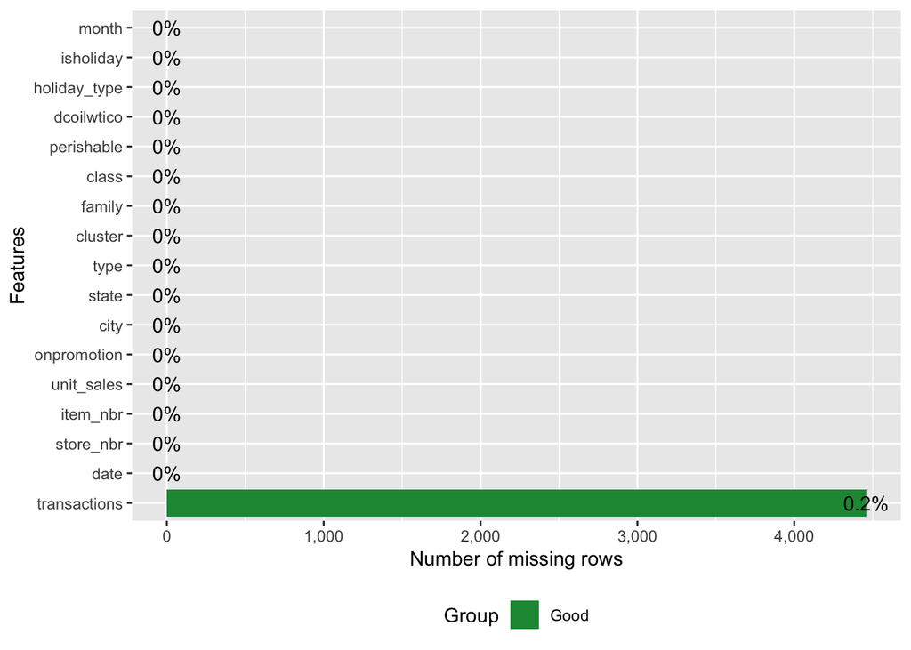

```r
plot_missing(final_data_model)
```

# EDA

## Overview of the final data

Let’s first take a look at the dataset after cleaning.

```r
library(Rmpfr)
glimpse(final_data_model)
```

```
## Observations: 2,184,032
## Variables: 17
## $ date         <fct> 2014-04-01, 2014-04-01, 2014-04-01, 2014-04-01, 2...
## $ store_nbr    <fct> 1, 1, 1, 1, 1, 1, 1, 1, 1, 1, 1, 1, 1, 1, 1, 1, 1...
## $ item_nbr     <fct> 264753, 357963, 461432, 577741, 577745, 657869, 6...
## $ unit_sales   <dbl> 6.000, 4.000, 1.000, 3.000, 3.000, 1.000, 3.000, ...
## $ onpromotion  <fct> FALSE, FALSE, FALSE, FALSE, FALSE, FALSE, FALSE, ...
## $ city         <fct> Quito, Quito, Quito, Quito, Quito, Quito, Quito, ...
## $ state        <fct> Pichincha, Pichincha, Pichincha, Pichincha, Pichi...
## $ type         <fct> D, D, D, D, D, D, D, D, D, D, D, D, D, D, D, D, D...
## $ cluster      <fct> 13, 13, 13, 13, 13, 13, 13, 13, 13, 13, 13, 13, 1...
## $ family       <fct> CLEANING, EGGS, AUTOMOTIVE, GROCERY I, GROCERY I,...
## $ class        <fct> 3034, 2502, 6810, 1032, 1032, 1004, 2644, 1062, 3...
## $ perishable   <fct> 0, 1, 0, 0, 0, 0, 1, 0, 0, 1, 0, 0, 1, 0, 0, 0, 0...
## $ transactions <int> 1847, 1847, 1847, 1847, 1847, 1847, 1847, 1847, 1...
## $ dcoilwtico   <dbl> 99.69, 99.69, 99.69, 99.69, 99.69, 99.69, 99.69, ...
## $ holiday_type <fct> Not holiday, Not holiday, Not holiday, Not holida...
## $ isholiday    <fct> 0, 0, 0, 0, 0, 0, 0, 0, 0, 0, 0, 0, 0, 0, 0, 0, 0...
## $ month        <fct> 4, 4, 4, 4, 4, 4, 4, 4, 4, 4, 4, 4, 4, 4, 4, 4, 4...
```

```r
plot_str(final_data_model)
introduce(final_data_model)
```

| rows | columns | discrete_columns | continuous_columns | all_missing_columns | total_missing_values | total_observations | memory_usage |
| --- | --- | --- | --- | --- | --- | --- | --- |
| 2184032 | 17 | 14 | 3 | 0 | 4458 | 37128544 | 166102328 |

## Understanding Key Variables

```
## 4 columns ignored with more than 50 categories.
## date: 1230 categories
## store_nbr: 54 categories
## item_nbr: 82 categories
## class: 59 categories
```

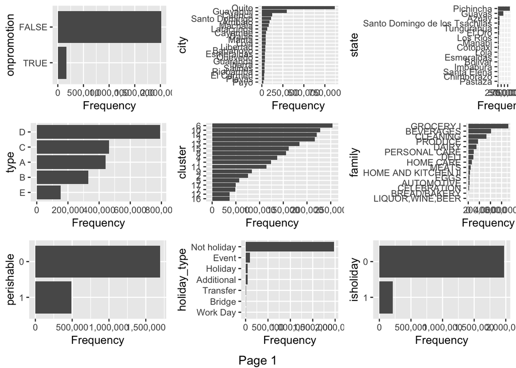

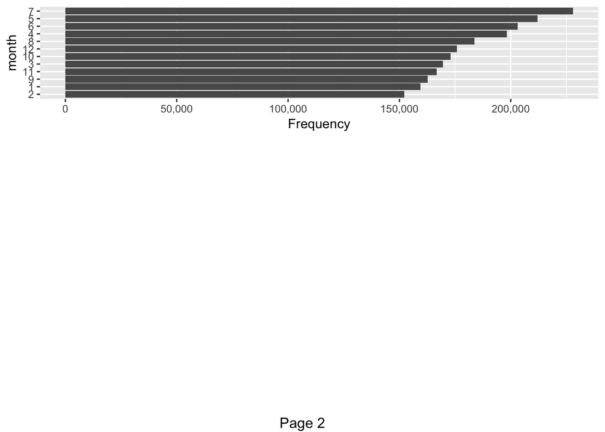

```r
plot_bar(final_data_model)
```

From our initial analysis, we find that (1)most of the items are not on promotion; (2)the city Quito has most of the stores; (3) the state Pichincha has most of the stores; (4) most of the days are not holidays.

We decide to look further into the store-related variables. In the following 2 figures, we use “city”, “state”, “type” and “cluster” to get a gengeral description of the stores in different cities and states.

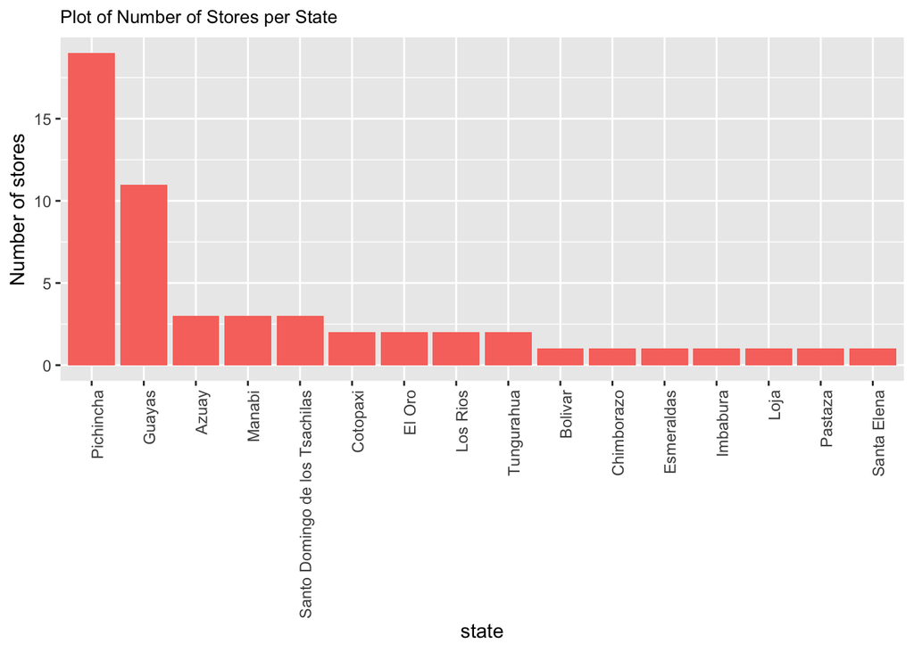

```r
g2<-final_data_model%>%
group_by(state) %>%
summarise(count_store_nbr=n_distinct(store_nbr))
ggplot(data=g2)+
geom_bar(
mapping=aes(x=reorder(state,-count_store_nbr),y=count_store_nbr,fill= "lightpink"),stat="identity"
) +
xlab("state") +
ylab("Number of stores") +
theme(axis.text.x = element_text(angle = 90, hjust = 1))+
ggtitle("Plot of Number of Stores per State") +
  theme(plot.title = element_text(size=10), legend.position="none")
```

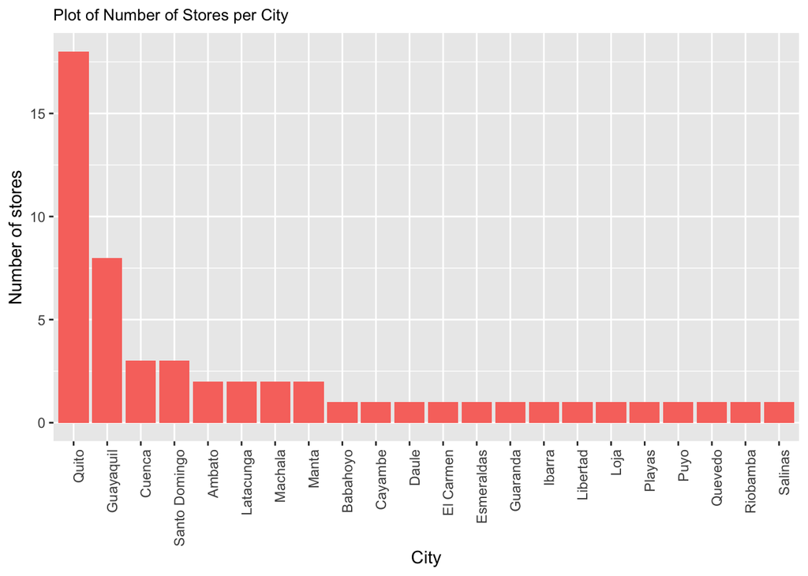

```r
g2<-final_data_model%>%
group_by(city) %>%
summarise(count_store_nbr=n_distinct(store_nbr))
ggplot(data=g2)+
geom_bar(
mapping=aes(x=reorder(city,-count_store_nbr),y=count_store_nbr, fill = "lightpink"),stat="identity"
) +
xlab("City") +
ylab("Number of stores") +
theme(axis.text.x = element_text(angle = 90, hjust = 1))+
ggtitle("Plot of Number of Stores per City") +
  theme(plot.title = element_text(size=10), legend.position="none")
```

These plots confirmed our initial observations that the stores center in two major states/cities and then scatter evenly in the rest of the states/cities.

## Correlation Analysis

After having a better understanding of the key data, let us look at the variables with high correlation to the unit sales.

```
## 10 features with more than 5 categories ignored!
## date: 1228 categories
## store_nbr: 54 categories
## item_nbr: 82 categories
## city: 22 categories
## state: 16 categories
## cluster: 17 categories
## family: 15 categories
## class: 59 categories
## holiday_type: 7 categories
## month: 12 categories
```

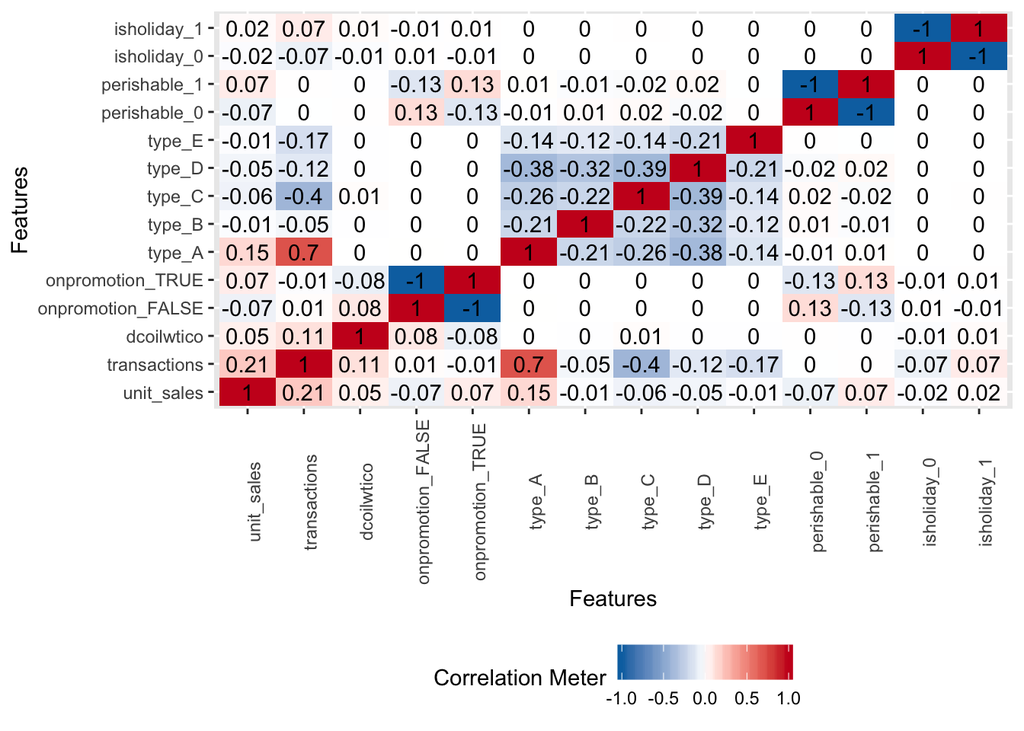

```r
plot_correlation(na.omit(final_data_model), maxcat = 5L)
```

From our observations above, we decide to explore further into the relationship between unit sales and store/item/oil price/promotion/holiday.

Let’s start with store type.

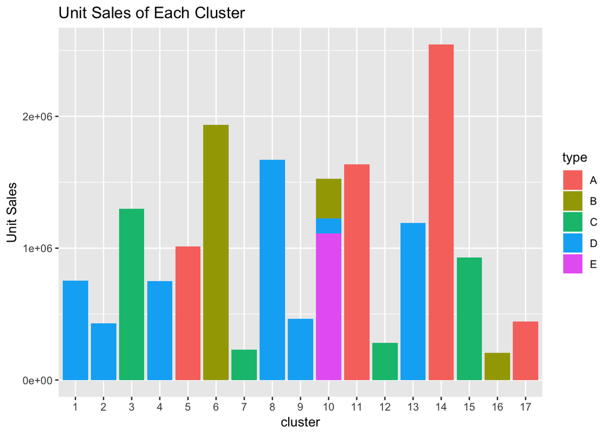

```r
ggplot(data = final_data_model, aes(x = cluster, y = unit_sales, fill = type)) +
  geom_bar(stat = 'identity')+
  labs(y = "Unit Sales", title = "Unit Sales of Each Cluster")
```

From this graph, we can see that basically each cluster contains one type of store (except for cluster 10 which contains three different types of stores). Stores in cluster 14 perform the best.

```r
multiplot <- function(..., plotlist=NULL, file, cols=1, layout=NULL) {
  require(grid)

  # Make a list from the ... arguments and plotlist
  plots <- c(list(...), plotlist)

  numPlots = length(plots)

  # If layout is NULL, then use 'cols' to determine layout
  if (is.null(layout)) {
    # Make the panel
    # ncol: Number of columns of plots
    # nrow: Number of rows needed, calculated from # of cols
    layout <- matrix(seq(1, cols * ceiling(numPlots/cols)),
                    ncol = cols, nrow = ceiling(numPlots/cols))
  }

 if (numPlots==1) {
    print(plots[[1]])
 } else {
    # Set up the page
    grid.newpage()
    pushViewport(viewport(layout = grid.layout(nrow(layout), ncol(layout))))

    # Make each plot, in the correct location
    for (i in 1:numPlots) {
      # Get the i,j matrix positions of the regions that contain this subplot
      matchidx <- as.data.frame(which(layout == i, arr.ind = TRUE))

      print(plots[[i]], vp = viewport(layout.pos.row = matchidx$row,
                                      layout.pos.col = matchidx$col))
    }
  }
}
```

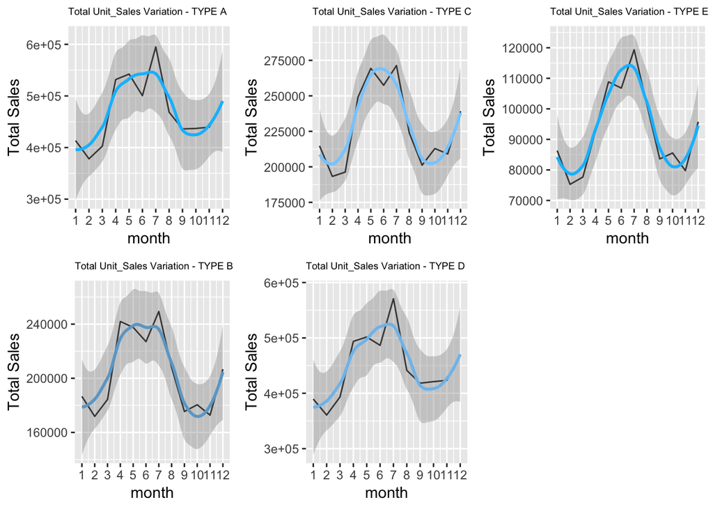

```r
final_data_model$month <- as.numeric(final_data_model$month)
l1<-final_data_model %>%
  filter(type=="A") %>%
  group_by(month) %>%
  summarise(sum_scale_A=sum(unit_sales))%>%
  ggplot(aes(x=month,y=sum_scale_A)) +
  geom_line(color="black",group=1) +
  geom_smooth(method="loess",color = "deepskyblue", span=3/5)+
  scale_x_continuous(breaks=c(8,9,10,11,12,1,2,3,4,5,6,7))+
  ylab("Total Sales") +
  ggtitle("Total Unit_Sales Variation - TYPE A")+
  theme(plot.title = element_text(size=7))

l2<-final_data_model %>%
  filter(type=="B") %>%
  group_by(month) %>%
  summarise(sum_scale_B=sum(unit_sales))%>%
  ggplot(aes(x=month,y=sum_scale_B)) +
  geom_line(color="black",group=1) +
  geom_smooth(method="loess",color = "skyblue3", span=3/5)+
  scale_x_continuous(breaks=c(8,9,10,11,12,1,2,3,4,5,6,7))+
  ylab("Total Sales") +
  ggtitle("Total Unit_Sales Variation - TYPE B")+
  theme(plot.title = element_text(size=7))

l3<-final_data_model %>%
  filter(type=="C") %>%
  group_by(month) %>%
  summarise(sum_scale_C=sum(unit_sales))%>%
  ggplot(aes(x=month,y=sum_scale_C)) +
  geom_line(color="black",group=1) +
  geom_smooth(method="loess",color = "skyblue1", span=3/5)+
  scale_x_continuous(breaks=c(8,9,10,11,12,1,2,3,4,5,6,7))+
  ylab("Total Sales") +
  ggtitle("Total Unit_Sales Variation - TYPE C")+
  theme(plot.title = element_text(size=7))

l4<-final_data_model %>%
  filter(type=="D") %>%
  group_by(month) %>%
  summarise(sum_scale_D=sum(unit_sales))%>%
  ggplot(aes(x=month,y=sum_scale_D)) +
  geom_line(color="black",group=1) +
  geom_smooth(method="loess",color = "skyblue2", span=3/5)+
  scale_x_continuous(breaks=c(8,9,10,11,12,1,2,3,4,5,6,7))+
  ylab("Total Sales") +
  ggtitle("Total Unit_Sales Variation - TYPE D")+
  theme(plot.title = element_text(size=7))
l5<-final_data_model %>%
  filter(type=="E") %>%
  group_by(month) %>%
  summarise(sum_scale_E=sum(unit_sales))%>%
  ggplot(aes(x=month,y=sum_scale_E)) +
  geom_line(color="black",group=1) +
  geom_smooth(method="loess",color = "deepskyblue", span=3/5)+
  scale_x_continuous(breaks=c(8,9,10,11,12,1,2,3,4,5,6,7))+
  ylab("Total Sales") +
  ggtitle("Total Unit_Sales Variation - TYPE E")+
  theme(plot.title = element_text(size=7))
  multiplot(l1,l2,l3,l4,l5,cols=3)
```

In these five plots, we get the total unit sales variation of five types of stores and we can tell that the total sales is: Type A and Type D > Type C > Type B > Type E.

Additionally, there is a significant seasonal trend in the overall unit sales: there is an upward trend from March to July, after peaking in July, it goes down.

Let’s look further at the transactions of different types of stores.

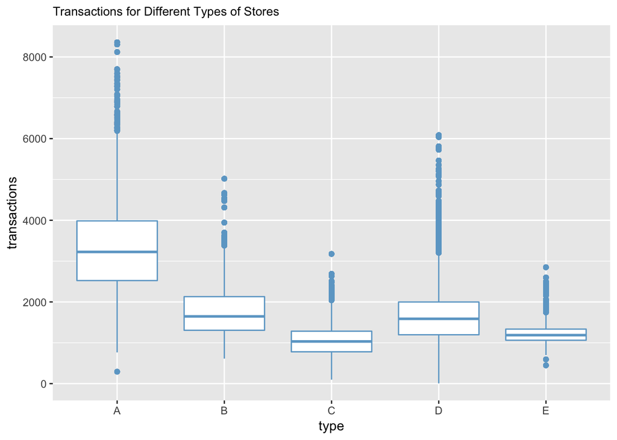

```r
final_data_model %>%
   ggplot(aes(x = type, y=transactions)) +
   geom_boxplot(color="skyblue3") +
   ggtitle("Transactions for Different Types of Stores") +
   theme(plot.title = element_text(size=10))
```

From this graph, we can see that type A stores have significantly higher number of transactions than other types of stores as well. In general, type A stores perform better than other stores.

In the second part of the correlation EDA, we will look at the relationship between item and unit sales, and we will use “family”, “class” and “perishable” to describe the characters of items.

```r
table(final_data_model$family)
```

```
##
##          AUTOMOTIVE           BEVERAGES        BREAD/BAKERY
##               20326              408491                1901
##         CELEBRATION            CLEANING               DAIRY
##               18588              329077              150890
##                DELI                EGGS           GROCERY I
##               92999               24148              721942
## HOME AND KITCHEN II           HOME CARE    LIQUOR,WINE,BEER
##               31454               65844                   7
##               MEATS       PERSONAL CARE             PRODUCE
##               46549               99238              172578
```

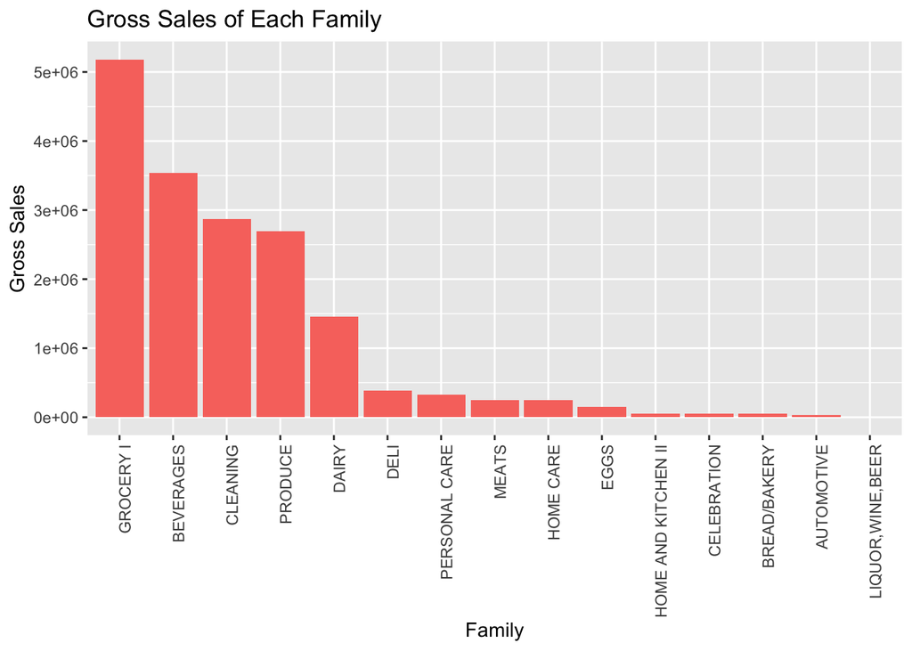

```r
g1<- final_data_model %>%
  group_by(family) %>%
  summarise(sale = sum(unit_sales))

g1 %>%
  ggplot(aes(x = reorder(family, -sale), y = sale, fill = "lightpink")) +
  geom_bar(stat = "identity")+
  labs(x = "Family", y = "Gross Sales", title = "Gross Sales of Each Family") +
  theme(axis.text.x = element_text(angle = 90, hjust = 1), legend.position="none")
```

There are in total 15 categories of family. Grocery I sells the best, followed by Beverage, Cleaning and Produce. The top 5 categories make up most of the sales.

Let’s take a closer look at the fluctuation in sales among the families. In this plot, we will take 4 families of items - GROCERY I, PERSONAL CARE, CLEANING and BEVERAGES - as examples to visualize their sales variation.

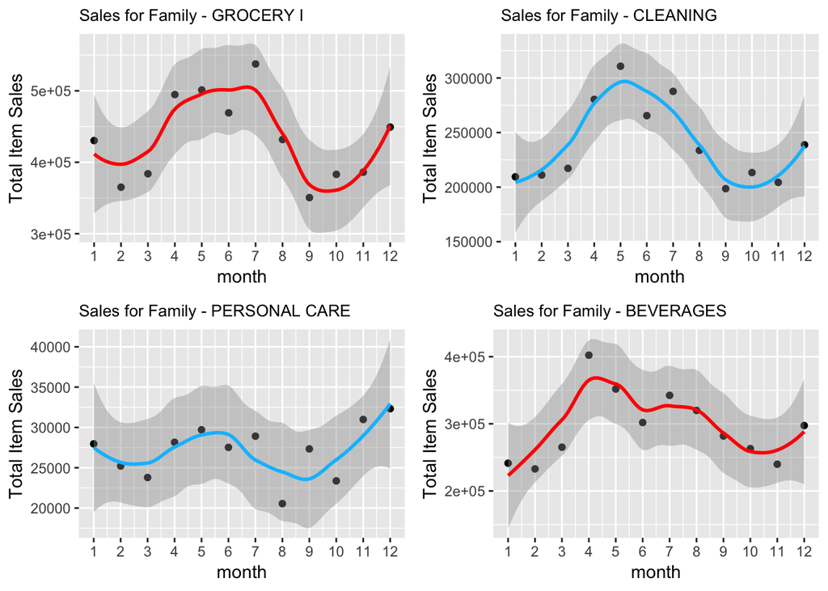

```r
 p1<-final_data_model %>%
  filter(family == "GROCERY I") %>%
  group_by(month) %>%
  summarise(sum_sales = sum(unit_sales)) %>%
  ggplot(aes(month, sum_sales)) +
  geom_point(color = "black",group=1) +
  geom_smooth(method = "loess", color = "red", span=3/5) +
  scale_x_continuous(breaks = c(8,9,10,11,12,1,2,3,4,5,6,7)) +
  ylab("Total Item Sales") +
  ggtitle("Sales for Family - GROCERY I")+
  theme(plot.title = element_text(size=10))

  p2<-final_data_model %>%
  filter(family == "PERSONAL CARE") %>%
  group_by(month) %>%
  summarise(sum_sales = sum(unit_sales)) %>%
  ggplot(aes(month, sum_sales)) +
  geom_point(color = "black",group=1) +
  geom_smooth(method = "loess", color = "deepskyblue", span=3/5) +
  scale_x_continuous(breaks = c(8,9,10,11,12,1,2,3,4,5,6,7)) +
  ylab("Total Item Sales") +
  ggtitle("Sales for Family - PERSONAL CARE")+
  theme(plot.title = element_text(size=10))

  p3<-final_data_model %>%
  filter(family == "CLEANING") %>%
  group_by(month) %>%
  summarise(sum_sales = sum(unit_sales)) %>%
  ggplot(aes(month, sum_sales)) +
  geom_point(color = "black",group=1) +
  geom_smooth(method = "loess", color = "deepskyblue", span=3/5) +
  scale_x_continuous(breaks = c(8,9,10,11,12,1,2,3,4,5,6,7)) +
  ylab("Total Item Sales") +
  ggtitle("Sales for Family - CLEANING")+
  theme(plot.title = element_text(size=10))

  p4<-final_data_model %>%
  filter(family == "BEVERAGES") %>%
  group_by(month) %>%
  summarise(sum_sales = sum(unit_sales)) %>%
  ggplot(aes(month, sum_sales)) +
  geom_point(color = "black",group=1) +
  geom_smooth(method = "loess", color = "red", span=3/5) +
  scale_x_continuous(breaks = c(8,9,10,11,12,1,2,3,4,5,6,7)) +
  ylab("Total Item Sales") +
  ggtitle("Sales for Family - BEVERAGES")+
  theme(plot.title = element_text(size=10))

  multiplot(p1,p2,p3,p4,cols=2)
```

From these four graphs, we can see there are large variations in the relationship between unit sales and different kinds of items. For example, grocery and beverages sell way more than cleaning and personal care. Also, the seasonal variations in each family also differs.

Besides 15 families, there are also various classes of items. We wonder what is the relationship between class and family.

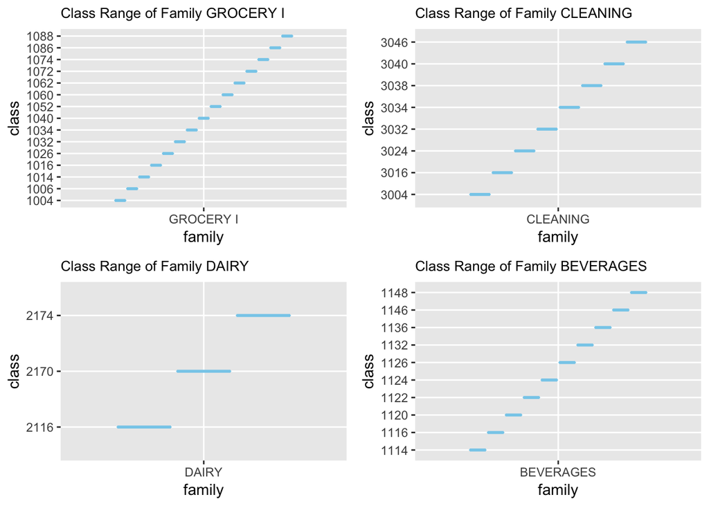

```r
final_data_model$class <- as.factor(final_data_model$class)
final_data_model$month <- as.factor(final_data_model$month)

data_i<-final_data_model %>%
  group_by(family) %>%
  filter(family=="GROCERY I") %>%
  select(family,class)

Y1<-data_i %>%
   ggplot(aes(x = family, y=class)) +
   geom_boxplot(color="skyblue") +
   ggtitle("Class Range of Family GROCERY I") +
   theme(plot.title = element_text(size=10))

data_i<-final_data_model %>%
  group_by(family) %>%
  filter(family=="DAIRY") %>%
  select(family,class)

Y2<-data_i %>%
   ggplot(aes(x = family, y=class)) +
   geom_boxplot(color="skyblue") +
   ggtitle("Class Range of Family DAIRY") +
   theme(plot.title = element_text(size=10))


data_i<-final_data_model %>%
  group_by(family) %>%
  filter(family=="CLEANING") %>%
  select(family,class)

Y3<-data_i %>%
   ggplot(aes(x = family, y=class)) +
   geom_boxplot(color="skyblue") +
   ggtitle("Class Range of Family CLEANING") +
   theme(plot.title = element_text(size=10))

data_i<-final_data_model %>%
  group_by(family) %>%
  filter(family=="BEVERAGES") %>%
  select(family,class)

Y4<-data_i %>%
   ggplot(aes(x = family, y=class)) +
   geom_boxplot(color="skyblue") +
   ggtitle("Class Range of Family BEVERAGES") +
   theme(plot.title = element_text(size=10))

  multiplot(Y1,Y2,Y3,Y4,cols=2)
```

From this preliminary analysis, we can deduct that family falls in certain range of class.

Next, let’s look at what is the relationship between oil price (which represents the macro-economic condition of the nation) and the unit sales.

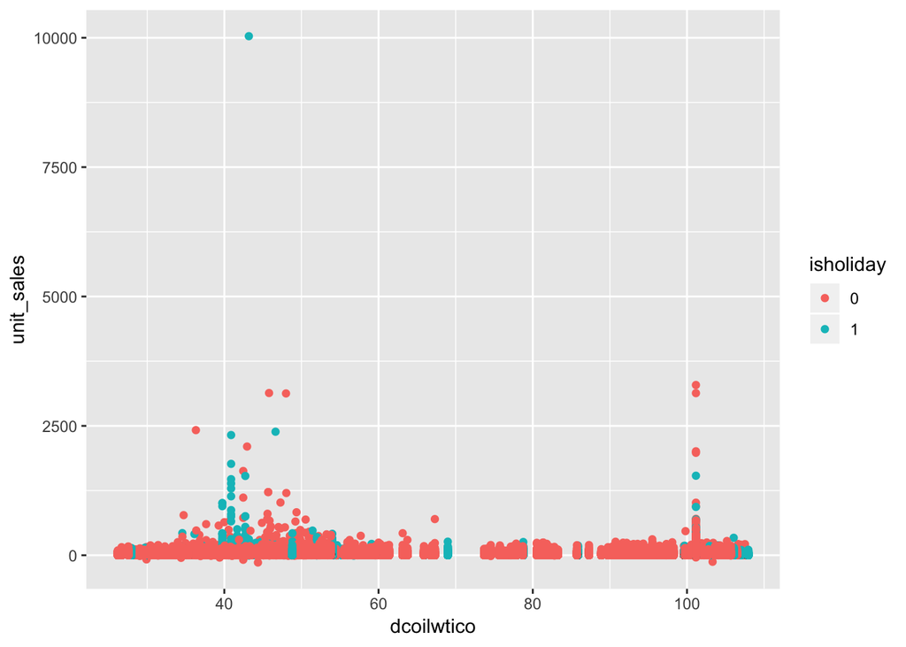

```r
ggplot(data = final_data_model, aes(x = dcoilwtico, y = unit_sales, color = isholiday)) +
  geom_point()
```

From this graph, there seems to be no strong correlation between oil price and the unit sales.

What about the relationship between promotion and unit sales?

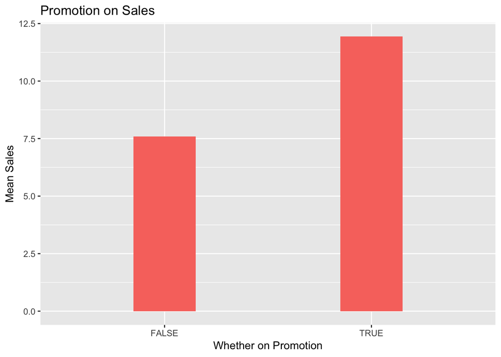

```r
final_data_model %>%
  group_by(onpromotion) %>%
  summarise(mean_sale = mean(unit_sales)) %>%
  ggplot(aes(x = onpromotion, y = mean_sale, width = 0.3, fill = "lightpink")) +
  geom_bar(stat = 'identity')+
  labs(x = 'Whether on Promotion', y = 'Mean Sales', title = 'Promotion on Sales') +
  theme(legend.position="none")
```

Finally, let’s look at the relationship between holiday and unit sales.

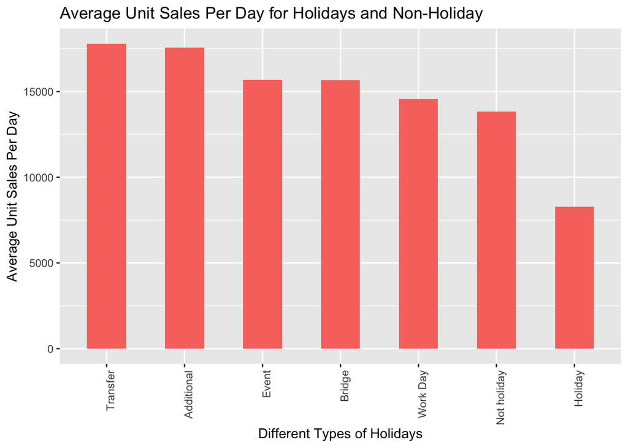

```r
A1<-final_data_model %>%
    filter(isholiday==1) %>%
    group_by(holiday_type) %>%
    summarise(average_unit_sales1=
    (sum_unit_sales1=sum(unit_sales)) / (count_unit_sales1=n_distinct(date)))

     A2<-final_data_model %>%
    group_by(holiday_type) %>%
    filter(isholiday==0) %>%
    summarise(average_unit_sales1=
    (sum_unit_sales1=sum(unit_sales)) / (count_unit_sales1=n_distinct(date)))

     merge_data<-merge(A1,A2,all=TRUE)

    ggplot(data=merge_data)+
     geom_bar(
     mapping=aes(x=(reorder(holiday_type,-average_unit_sales1)),y=average_unit_sales1, fill = "lightpink"),stat="identity",width=0.5
  ) +
    xlab("Different Types of Holidays") +
    ylab("Average Unit Sales Per Day") +
theme(axis.text.x = element_text(angle = 90, hjust = 1)) +
     ggtitle("Average Unit Sales Per Day for Holidays and Non-Holiday") +
      theme(legend.position="none")
```

From this graph, we can see that most of the holiday types perform better than non-holidays, especially the ‘Transfer’ and the ‘Additional’. Psychologically, this might be because these types of holidays were not supposed to be holidays in the first place, so the public might treat them especially specially. An interesting observation here is that the ‘holiday’ type holidays do not perform as well as the non-holidays.

# Modeling

## Data splitting

1. we set see to 100 to make sure that our data can be reproduced
2. we split the model data into training and testing sets.

```r
set.seed(100)
inTraining <- createDataPartition(final_data_model$item_nbr, p=0.7, list=FALSE)
train_data <- final_data_model[inTraining,]
test_data <- final_data_model[-inTraining,]
```

## Correlation analysis

1.Before we run our base model, we looked at correlation table to check collinearity among all variables. 2. we used our correlation analysis to get rid of variables with high multi-collinearity to make our model are efficient and simple. 3. load the library and run our correlation analysis

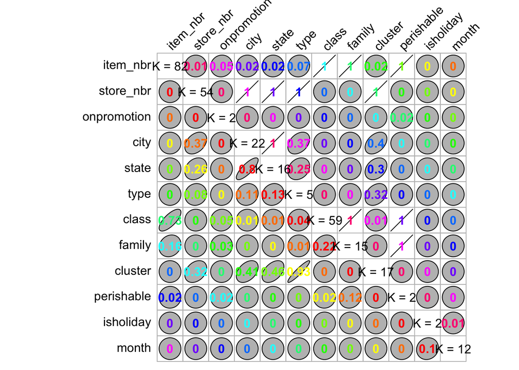

```r
library(GoodmanKruskal)
varSet <- c("item_nbr", "store_nbr", "onpromotion", "city", "state", "type", "class", "family", "cluster", "perishable", "isholiday", "month")
Corframe <- subset(final_data_model, select = varSet)
Cormatrix <- GKtauDataframe(Corframe)
plot(Cormatrix)
```

## conclusion from our correlation anlysis

1. we found store_nbr is highly correlated with city, state, type and cluster;
2. item_nbr is highly correlated with class, family and perishable;
3. city is highly correlated with state; cluster is highly correlated with type;
4. class and family are highly correlated with family and perishable.
5. Therefore, when we take fixed effects in the linear regression model, we have to be very careful to figure out which variable to include and which variable to exclude.
6. we should not regress our dependent variable on multiple highly-correlated predictors simutaneously.
7. For example, if we use store-fixed effect, we would eliminate state and city in our model. If we use item-fixed effect, we would get rid of class, family and perishable.

## Base model

```r
mod1 <- lm( data=train_data, formula=unit_sales ~ item_nbr + store_nbr + onpromotion + city + state + type + class + family + cluster + perishable + dcoilwtico + isholiday + holiday_type + month)
summary(mod1)
```

```
##
## Call:
## lm(formula = unit_sales ~ item_nbr + store_nbr + onpromotion +
##     city + state + type + class + family + cluster + perishable +
##     dcoilwtico + isholiday + holiday_type + month, data = train_data)
##
## Residuals:
##     Min      1Q  Median      3Q     Max
##   -89.5    -4.2    -0.6     2.5 10020.6
##
## Coefficients: (130 not defined because of singularities)
##                                      Estimate Std. Error t value Pr(>|t|)
## (Intercept)                         -1.038866   0.145185  -7.155 8.34e-13
## item_nbr357963                      -0.428287   0.156010  -2.745 0.006047
## item_nbr428394                      -5.401221   0.240857 -22.425  < 2e-16
## item_nbr461432                      -2.449407   0.164471 -14.893  < 2e-16
## item_nbr577741                       4.477931   0.127943  34.999  < 2e-16
## item_nbr577745                      -0.015892   0.141305  -0.112 0.910456
## item_nbr584125                       0.804768   0.157256   5.118 3.10e-07
## item_nbr657869                       1.527803   0.128364  11.902  < 2e-16
## item_nbr671083                       0.859487   0.127986   6.715 1.87e-11
## item_nbr671908                      -2.863206   0.138428 -20.684  < 2e-16
## item_nbr683720                      -1.007714   0.133643  -7.540 4.69e-14
## item_nbr757889                       8.865858   0.151820  58.397  < 2e-16
## item_nbr770449                      27.969913   0.163945 170.605  < 2e-16
## item_nbr796395                       0.711085   0.148398   4.792 1.65e-06
## item_nbr816679                       0.780741   0.159768   4.887 1.03e-06
## item_nbr830829                       1.624691   0.130202  12.478  < 2e-16
## item_nbr848953                      -2.589485   0.151062 -17.142  < 2e-16
## item_nbr852110                      13.096965   0.134720  97.216  < 2e-16
## item_nbr859966                       5.029004   0.137861  36.479  < 2e-16
## item_nbr911990                       1.563082   0.138026  11.325  < 2e-16
## item_nbr916886                       5.971156   0.149432  39.959  < 2e-16
## item_nbr953562                       0.004097   0.129742   0.032 0.974809
## item_nbr959502                       4.388316   0.128232  34.222  < 2e-16
## item_nbr964753                       2.999138   0.130208  23.033  < 2e-16
## item_nbr1024975                      9.592599   0.153649  62.432  < 2e-16
## item_nbr1040348                      0.102702   0.161790   0.635 0.525569
## item_nbr1047690                     22.926693   0.127059 180.441  < 2e-16
## item_nbr1047707                     -0.997546   0.137466  -7.257 3.97e-13
```

[output cut: 532 more lines]

```
## month4                              ***
## month5                              ***
## month6                              ***
## month7                              ***
## month8                              ***
## month9                              ***
## month10                             ***
## month11                             ***
## month12                             ***
## ---
## Signif. codes:  0 '***' 0.001 '**' 0.01 '*' 0.05 '.' 0.1 ' ' 1
##
## Residual standard error: 15.51 on 1528703 degrees of freedom
## Multiple R-squared:  0.1907, Adjusted R-squared:  0.1906
## F-statistic:  2354 on 153 and 1528703 DF,  p-value: < 2.2e-16
```

```r
pred1 <- predict(object = mod1, newdata = test_data)
```

## evaluation of our base model

we wrote a function to calculate Root-Mean Sqaure Error. We calculate the RMSE for model 1, it is 13.25.

```r
rmse <- function(error){
  sqrt(mean(error^2, na.rm = TRUE))
}

error_mod1 <- test_data$unit_sales - pred1
rmse_mod1 <- rmse(error_mod1)
```

## refine the base model

```r
mod2 <- lm(formula = unit_sales ~ store_nbr + item_nbr + onpromotion + dcoilwtico + holiday_type, data=train_data)
summary(mod2)
```

```
##
## Call:
## lm(formula = unit_sales ~ store_nbr + item_nbr + onpromotion +
##     dcoilwtico + holiday_type, data = train_data)
##
## Residuals:
##     Min      1Q  Median      3Q     Max
##   -89.5    -4.2    -0.6     2.5 10020.8
##
## Coefficients:
##                           Estimate Std. Error t value Pr(>|t|)
## (Intercept)              0.0730545  0.1646136   0.444 0.657192
## store_nbr2               1.9167662  0.1235592  15.513  < 2e-16 ***
## store_nbr3               9.3177615  0.1204882  77.333  < 2e-16 ***
## store_nbr4               1.9012768  0.1275513  14.906  < 2e-16 ***
## store_nbr5               0.5404357  0.1254534   4.308 1.65e-05 ***
## store_nbr6               3.0937807  0.1233541  25.080  < 2e-16 ***
## store_nbr7               4.1470713  0.1256328  33.009  < 2e-16 ***
## store_nbr8               4.4497597  0.1222159  36.409  < 2e-16 ***
## store_nbr9               3.3394686  0.1238163  26.971  < 2e-16 ***
## store_nbr10             -1.8486619  0.1398325 -13.221  < 2e-16 ***
## store_nbr11              3.4451321  0.1252511  27.506  < 2e-16 ***
## store_nbr12             -0.9787712  0.1403469  -6.974 3.08e-12 ***
## store_nbr13             -0.7591129  0.1393310  -5.448 5.09e-08 ***
## store_nbr14             -0.8274931  0.1416272  -5.843 5.14e-09 ***
## store_nbr15             -1.5367228  0.1392234 -11.038  < 2e-16 ***
## store_nbr16             -1.5097733  0.1387354 -10.882  < 2e-16 ***
## store_nbr17              1.6603559  0.1343001  12.363  < 2e-16 ***
## store_nbr18             -0.3137231  0.1341164  -2.339 0.019326 *
## store_nbr19              0.6427200  0.1366067   4.705 2.54e-06 ***
## store_nbr20              2.0538234  0.1338224  15.347  < 2e-16 ***
## store_nbr21             -0.2862048  0.1395824  -2.050 0.040322 *
## store_nbr22             -2.7247536  0.1641525 -16.599  < 2e-16 ***
## store_nbr23             -1.1460100  0.1307684  -8.764  < 2e-16 ***
## store_nbr24              2.0854434  0.1264408  16.493  < 2e-16 ***
## store_nbr25             -1.5352989  0.1395290 -11.003  < 2e-16 ***
## store_nbr26             -2.4621124  0.1383369 -17.798  < 2e-16 ***
## store_nbr27              1.6678873  0.1252848  13.313  < 2e-16 ***
## store_nbr28              1.0035097  0.1291046   7.773 7.68e-15 ***
## store_nbr29             -0.0092729  0.1393696  -0.067 0.946952
```

[output cut: 105 more lines]

```
## item_nbr2122676         -5.7143498  2.2655260  -2.522 0.011659 *
## onpromotionTRUE          4.3564447  0.0485969  89.645  < 2e-16 ***
## dcoilwtico               0.0410014  0.0004729  86.709  < 2e-16 ***
## holiday_typeBridge       1.1498300  0.2780198   4.136 3.54e-05 ***
## holiday_typeEvent       -0.6461731  0.1075789  -6.007 1.90e-09 ***
## holiday_typeHoliday     -0.3328657  0.1242372  -2.679 0.007378 **
## holiday_typeNot holiday -1.4497144  0.0907464 -15.975  < 2e-16 ***
## holiday_typeTransfer    -0.4971640  0.1888913  -2.632 0.008488 **
## holiday_typeWork Day    -1.2562744  0.2795814  -4.493 7.01e-06 ***
## ---
## Signif. codes:  0 '***' 0.001 '**' 0.01 '*' 0.05 '.' 0.1 ' ' 1
##
## Residual standard error: 15.51 on 1528714 degrees of freedom
## Multiple R-squared:  0.1904, Adjusted R-squared:  0.1903
## F-statistic:  2532 on 142 and 1528714 DF,  p-value: < 2.2e-16
```

```r
pred2 <- predict(object = mod2, newdata = test_data)

error_mod2 <- test_data$unit_sales - pred2
rmse_mod2 <- rmse(error_mod2)
```

## refine the second model

```r
library(plm)
mod3 <- lm(formula = unit_sales ~ store_nbr + item_nbr + onpromotion + dcoilwtico + holiday_type, data=train_data, weights = dcoilwtico)
summary(mod3)
```

```
##
## Call:
## lm(formula = unit_sales ~ store_nbr + item_nbr + onpromotion +
##     dcoilwtico + holiday_type, data = train_data, weights = dcoilwtico)
##
## Weighted Residuals:
##    Min     1Q Median     3Q    Max
##   -576    -34     -3     22  65850
##
## Coefficients:
##                           Estimate Std. Error t value Pr(>|t|)
## (Intercept)             -1.2187002  0.1599105  -7.621 2.52e-14 ***
## store_nbr2               2.4463045  0.1197398  20.430  < 2e-16 ***
## store_nbr3              10.2800796  0.1169647  87.890  < 2e-16 ***
## store_nbr4               2.4794086  0.1234397  20.086  < 2e-16 ***
## store_nbr5               0.9216463  0.1214893   7.586 3.30e-14 ***
## store_nbr6               3.6869101  0.1195133  30.849  < 2e-16 ***
## store_nbr7               4.2571519  0.1220217  34.888  < 2e-16 ***
## store_nbr8               5.0830170  0.1185750  42.868  < 2e-16 ***
## store_nbr9               4.0998406  0.1200164  34.161  < 2e-16 ***
## store_nbr10             -1.5138143  0.1345973 -11.247  < 2e-16 ***
## store_nbr11              3.9604663  0.1212681  32.659  < 2e-16 ***
## store_nbr12             -0.6710633  0.1358242  -4.941 7.79e-07 ***
## store_nbr13             -0.3811677  0.1345270  -2.833 0.004606 **
## store_nbr14             -0.4729490  0.1368986  -3.455 0.000551 ***
## store_nbr15             -1.3691515  0.1348616 -10.152  < 2e-16 ***
## store_nbr16             -1.0711051  0.1337915  -8.006 1.19e-15 ***
## store_nbr17              2.1732079  0.1300220  16.714  < 2e-16 ***
## store_nbr18              0.1413255  0.1291035   1.095 0.273662
## store_nbr19              1.0403306  0.1319667   7.883 3.19e-15 ***
## store_nbr20              2.7683989  0.1317197  21.017  < 2e-16 ***
## store_nbr21              0.3198671  0.1380168   2.318 0.020471 *
## store_nbr22             -2.4851962  0.1628650 -15.259  < 2e-16 ***
## store_nbr23             -0.8566820  0.1264651  -6.774 1.25e-11 ***
## store_nbr24              2.3365329  0.1234965  18.920  < 2e-16 ***
## store_nbr25             -1.3074429  0.1349415  -9.689  < 2e-16 ***
## store_nbr26             -2.1726178  0.1330431 -16.330  < 2e-16 ***
## store_nbr27              2.1395901  0.1213476  17.632  < 2e-16 ***
## store_nbr28              1.5194238  0.1247406  12.181  < 2e-16 ***
## store_nbr29              0.4839478  0.1374363   3.521 0.000430 ***
```

[output cut: 105 more lines]

```
## item_nbr2122676         -6.0442129  2.1910198  -2.759 0.005804 **
## onpromotionTRUE          4.4750307  0.0493521  90.676  < 2e-16 ***
## dcoilwtico               0.0427841  0.0004692  91.180  < 2e-16 ***
## holiday_typeBridge       1.6555402  0.3116664   5.312 1.09e-07 ***
## holiday_typeEvent       -0.5041057  0.1031876  -4.885 1.03e-06 ***
## holiday_typeHoliday     -0.3248735  0.1194069  -2.721 0.006514 **
## holiday_typeNot holiday -1.0399415  0.0874894 -11.886  < 2e-16 ***
## holiday_typeTransfer     0.1653110  0.1884375   0.877 0.380339
## holiday_typeWork Day    -0.8952857  0.2278544  -3.929 8.52e-05 ***
## ---
## Signif. codes:  0 '***' 0.001 '**' 0.01 '*' 0.05 '.' 0.1 ' ' 1
##
## Residual standard error: 124.3 on 1528714 degrees of freedom
## Multiple R-squared:  0.2191, Adjusted R-squared:  0.219
## F-statistic:  3020 on 142 and 1528714 DF,  p-value: < 2.2e-16
```

```r
pred3 <- predict(object = mod3, newdata = test_data)

error_mod3 <- test_data$unit_sales - pred3
rmse_mod3 <- rmse(error_mod3)
```

## refine the third model and derive our final model 4 (huge imrovement!)

```r
mod4 <- lm(formula = unit_sales ~ store_nbr + item_nbr + onpromotion + dcoilwtico + I(dcoilwtico^2) + holiday_type, data=test_data, weights = dcoilwtico)
summary(mod4)
```

```
##
## Call:
## lm(formula = unit_sales ~ store_nbr + item_nbr + onpromotion +
##     dcoilwtico + I(dcoilwtico^2) + holiday_type, data = test_data,
##     weights = dcoilwtico)
##
## Weighted Residuals:
##     Min      1Q  Median      3Q     Max
## -1533.8   -34.0    -3.1    21.3 21612.1
##
## Coefficients:
##                           Estimate Std. Error t value Pr(>|t|)
## (Intercept)              2.036e+00  3.506e-01   5.808 6.33e-09 ***
## store_nbr2               2.574e+00  1.581e-01  16.276  < 2e-16 ***
## store_nbr3               1.016e+01  1.540e-01  65.973  < 2e-16 ***
## store_nbr4               2.284e+00  1.634e-01  13.976  < 2e-16 ***
## store_nbr5               9.465e-01  1.599e-01   5.918 3.26e-09 ***
## store_nbr6               3.754e+00  1.579e-01  23.782  < 2e-16 ***
## store_nbr7               4.232e+00  1.613e-01  26.235  < 2e-16 ***
## store_nbr8               5.172e+00  1.566e-01  33.029  < 2e-16 ***
## store_nbr9               4.103e+00  1.585e-01  25.892  < 2e-16 ***
## store_nbr10             -1.485e+00  1.776e-01  -8.365  < 2e-16 ***
## store_nbr11              3.782e+00  1.602e-01  23.607  < 2e-16 ***
## store_nbr12             -8.015e-01  1.787e-01  -4.485 7.30e-06 ***
## store_nbr13             -3.033e-01  1.776e-01  -1.707 0.087777 .
## store_nbr14             -4.528e-01  1.807e-01  -2.505 0.012232 *
## store_nbr15             -1.384e+00  1.784e-01  -7.757 8.69e-15 ***
## store_nbr16             -1.101e+00  1.766e-01  -6.232 4.59e-10 ***
## store_nbr17              2.169e+00  1.721e-01  12.601  < 2e-16 ***
## store_nbr18              2.036e-01  1.706e-01   1.194 0.232613
## store_nbr19              1.051e+00  1.744e-01   6.023 1.71e-09 ***
## store_nbr20              2.595e+00  1.737e-01  14.933  < 2e-16 ***
## store_nbr21              1.984e-01  1.829e-01   1.085 0.278101
## store_nbr22             -2.498e+00  2.132e-01 -11.714  < 2e-16 ***
## store_nbr23             -7.554e-01  1.670e-01  -4.523 6.11e-06 ***
## store_nbr24              2.366e+00  1.630e-01  14.513  < 2e-16 ***
## store_nbr25             -1.203e+00  1.778e-01  -6.765 1.33e-11 ***
## store_nbr26             -2.247e+00  1.756e-01 -12.793  < 2e-16 ***
## store_nbr27              2.094e+00  1.603e-01  13.063  < 2e-16 ***
## store_nbr28              1.485e+00  1.653e-01   8.985  < 2e-16 ***
```

[output cut: 107 more lines]

```
## onpromotionTRUE          4.411e+00  6.509e-02  67.771  < 2e-16 ***
## dcoilwtico              -6.409e-02  8.850e-03  -7.241 4.45e-13 ***
## I(dcoilwtico^2)          7.268e-04  6.011e-05  12.092  < 2e-16 ***
## holiday_typeBridge       1.676e+00  4.142e-01   4.045 5.22e-05 ***
## holiday_typeEvent       -8.036e-01  1.360e-01  -5.911 3.41e-09 ***
## holiday_typeHoliday     -5.402e-01  1.579e-01  -3.422 0.000623 ***
## holiday_typeNot holiday -1.012e+00  1.154e-01  -8.763  < 2e-16 ***
## holiday_typeTransfer     3.037e-01  2.486e-01   1.221 0.221920
## holiday_typeWork Day    -1.410e+00  3.014e-01  -4.679 2.88e-06 ***
## ---
## Signif. codes:  0 '***' 0.001 '**' 0.01 '*' 0.05 '.' 0.1 ' ' 1
##
## Residual standard error: 107.1 on 655031 degrees of freedom
## Multiple R-squared:  0.2714, Adjusted R-squared:  0.2713
## F-statistic:  1707 on 143 and 655031 DF,  p-value: < 2.2e-16
```

```r
pred4 <- predict(object = mod4, newdata = test_data)

error_mod4 <- test_data$unit_sales - pred4
rmse_mod4 <- rmse(error_mod4)

pred_real <- predict(object = mod3, newdata = final_data_pred)
```